# Practical Batch-Effects

Maarten van Iterson  
July 4, 2017

- Introduction
- Get the data:
- Finding diff. expr. genes using `limma` or `edgeR`
  - Preprocessing and data inspection
  - Fitting using `voom`
- Batch effect correction using *RUVseq*
- Batch effect correction using *sva*
- References

# Introduction

In this practical you will learn how to perform batch correction on RNAseq data using the packages RUVSeq and sva. The example data that will be used is a subset of the HapMap RNAseq data described by Pickrell and Montgomery (Pickrell et al. 2010, Montgomery et al. (2010)). A combined dataset containing the RNAseq data of both papers is available from the ReCount website (Frazee, Langmead, and Leek 2011). As phenotype information we have Population (CEU/YRI) and Gender (Male/Female). In some of the Exercises we will assume the population origin of the samples is a unknown batch effect.

The practical consists of four parts:

- download the data and some preprocessing
- find diff. expr. genes between Male/Female using limma's `voom` or edgeR with population as a known batch in the design matrix
- estimate batch effects using RUVSeq and find diff. expr. genes
- estimate batch effects using sva and find diff. expr. genes

# Get the data:

Run the following two code chunks to get the data in your R-environment.

```r
library(Biobase)
monpick <- "http://bowtie-bio.sourceforge.net/recount/ExpressionSets/montpick_eset.RData"
load(url(monpick))
head(pData(montpick.eset))
```

```
##         sample.id num.tech.reps population      study
## NA06985   NA06985             1        CEU Montgomery
## NA06986   NA06986             1        CEU Montgomery
## NA06994   NA06994             1        CEU Montgomery
## NA07000   NA07000             1        CEU Montgomery
## NA07037   NA07037             1        CEU Montgomery
## NA07051   NA07051             1        CEU Montgomery
```

```r
counts <- exprs(montpick.eset)
counts[1:5, 1:5]
```

```
##                 NA06985 NA06986 NA06994 NA07000 NA07037
## ENSG00000000003       0       0       0       1       0
## ENSG00000000005       0       0       0       0       0
## ENSG00000000419      11      16      10      19       8
## ENSG00000000457      28      22      17      21      18
## ENSG00000000460       0       7       2       4       6
```

Unfortunately, gender information is not provided. This can be obtained from the 1000genomes website: ftp://ftp.1000genomes.ebi.ac.uk/vol1/ftp/technical/working/20130606_sample_info/20130606_sample_info.xlsx Download the sample information file and save the sheet with sample info as csv-file and preprocess like this:

```r
sample.info.file <- "https://raw.githubusercontent.com/molepi/MOLMED2017/master/Practical_BatchEffect/20130606_sample_info.csv"
sample.info <- read.table(url(sample.info.file), header=TRUE, sep="\t")
head(sample.info)
```

```
##    Sample Family.ID Population          Population.Description Gender
## 1 HG00096   HG00096        GBR British in England and Scotland   male
## 2 HG00097   HG00097        GBR British in England and Scotland female
## 3 HG00098   HG00098        GBR British in England and Scotland   male
## 4 HG00099   HG00099        GBR British in England and Scotland female
## 5 HG00100   HG00100        GBR British in England and Scotland female
## 6 HG00101   HG00101        GBR British in England and Scotland   male
##   Relationship Unexpected.Parent.Child Non.Paternity Siblings Grandparents
## 1
## 2
## 3
## 4
## 5
## 6
##   Avuncular Half.Siblings Unknown.Second.Order Third.Order Other.Comments
## 1                                                                      NA
## 2                                                                      NA
## 3                                                                      NA
## 4                                                                      NA
## 5                                                                      NA
## 6                                                                      NA
```

```r
pdata <- merge(pData(montpick.eset), sample.info, by.x="sample.id", by.y="Sample", all.x=TRUE)
pdata[is.na(pdata$Gender),]
```

```
##     sample.id num.tech.reps population    study Family.ID Population
## 117   NA19192             2        YRI Pickrell      <NA>       <NA>
## 118   NA19193             2        YRI Pickrell      <NA>       <NA>
##     Population.Description Gender Relationship Unexpected.Parent.Child
## 117                   <NA>   <NA>         <NA>                    <NA>
## 118                   <NA>   <NA>         <NA>                    <NA>
##     Non.Paternity Siblings Grandparents Avuncular Half.Siblings
## 117          <NA>     <NA>         <NA>      <NA>          <NA>
## 118          <NA>     <NA>         <NA>      <NA>          <NA>
##     Unknown.Second.Order Third.Order Other.Comments
## 117                 <NA>        <NA>             NA
## 118                 <NA>        <NA>             NA
```

```r
counts <- counts[,!is.na(pdata$Gender)]
pdata <- pdata[!is.na(pdata$Gender),]
pdata <- droplevels(pdata)
dim(pdata)
```

```
## [1] 127  18
```

```r
dim(counts)
```

```
## [1] 52580   127
```

We had to remove two samples because for these no phenotype information was available. Furthermore, we dropped the additional factor levels as these will interfere later with the creation of design-matrices.

Now we can start our analyzes!

# Finding diff. expr. genes using `limma` or `edgeR`

First we will find diff. expr. genes using either limma's `voom` or edgeR which one is up to you!

## Preprocessing and data inspection

> Exercise 1: Construct a *egdeR* `DGEList` with a group-variable the Gender information. Optionally, remove low expressed genes.

*Solution 1:*

```r
isexpr <- rowSums(counts) > 50
counts <- counts[isexpr,]
dim(counts)
```

```
## [1] 9085  127
```

```r
library(edgeR)
d <- DGEList(counts, group=pdata$Gender)
d <- calcNormFactors(d)
```

> Exercise 2: Inspect the data using a Multi-dimensional scaling plot to see potential batches in the data. Use coloring and labels to see which, gender or population, has the strongest effect.

*Solution 2:*

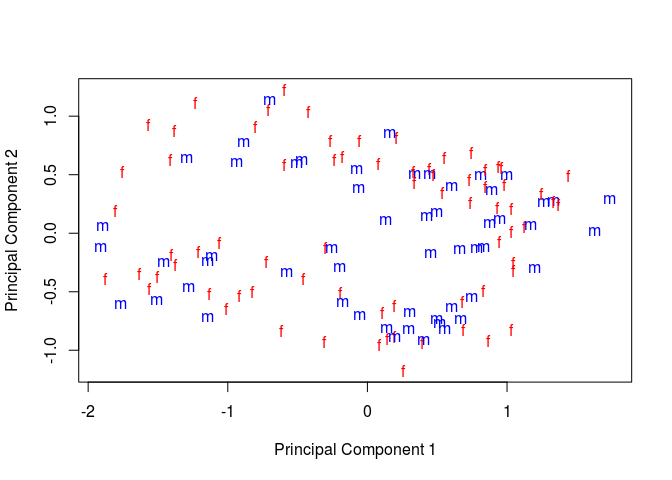

```r
Gender <- substring(pdata$Gender,1,1)
colGen <- ifelse(Gender=="m","blue","red")
plotMDS(d, labels = Gender,top = 50, col=colGen, gene.selection="common", prior.count = 5)
```

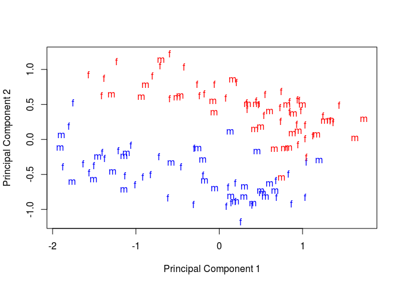

```r
Population <- substring(pdata$population,1,1)
colPop <- ifelse(Population=="C","blue","red")
plotMDS(d, labels = Gender,top = 50, col=colPop, gene.selection="common", prior.count = 5)
```

## Fitting using `voom`

> Exercise 3a: Fit a linear model correcting for the population structure using `voom`.

*Solution 3a:*

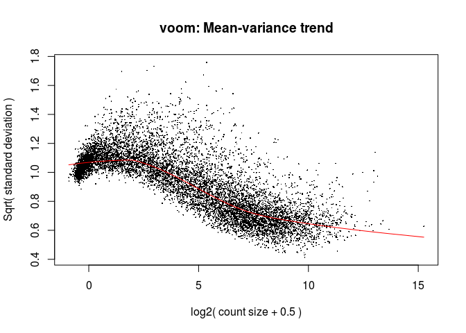

```r
design <- model.matrix(~Gender + Population, data = pdata)
v <- voom(d, design, plot = TRUE)
```

```r
fit <- lmFit(v, design)
fit <- eBayes(fit)
```

```r
summary(decideTests(fit))
```

```
##    (Intercept) Gendermale PopulationYRI
## -1        1490          8          2505
## 0          720       9059          3780
## 1         6875         18          2800
```

```r
topTable(fit)
```

```
## Removing intercept from test coefficients

##                  Gendermale PopulationYRI     AveExpr         F
## ENSG00000129824  8.59843720   -0.10666014 2.303870943 1331.0881
## ENSG00000099749  5.38177831    0.01755708 0.560818136  548.0786
## ENSG00000154620  4.76975249   -0.76318939 0.917947739  459.6110
## ENSG00000198692  4.34208054   -0.07781427 0.062664870  252.1678
## ENSG00000157828  3.88044378   -0.79429515 0.003851596  211.1734
## ENSG00000175265  0.34974300    4.13948895 2.492853178  155.2317
## ENSG00000172638 -0.03352651    3.73612155 3.513702544  147.6890
## ENSG00000152795  0.15797888    2.94887391 0.980299050  138.5802
## ENSG00000135473  0.26366058    1.77986395 7.215823299  133.3356
## ENSG00000033030  0.11170019    1.04261373 6.834586594  128.3276
##                      P.Value    adj.P.Val
## ENSG00000129824 4.848864e-88 4.405193e-84
## ENSG00000099749 1.521134e-64 6.909753e-61
## ENSG00000154620 4.258737e-60 1.289688e-56
## ENSG00000198692 9.587573e-46 2.177578e-42
## ENSG00000157828 8.437196e-42 1.533039e-38
## ENSG00000175265 2.364099e-35 3.579640e-32
## ENSG00000172638 2.322201e-34 3.013885e-31
## ENSG00000152795 4.092192e-33 4.647196e-30
## ENSG00000135473 2.263856e-32 2.285237e-29
## ENSG00000033030 1.209844e-31 1.099143e-28
```

> Exercise 3b: Fit a linear model correcting for the population structure using *edgeR* (you can reuse the `DGEList`).

*Solution 3b:*

```r
d1 <- estimateGLMCommonDisp(d, design)
d1 <- estimateGLMTagwiseDisp(d1, design)
```

```r
fit <- glmFit(d1, design)
lrt <- glmLRT(fit, coef=2)
topTags(lrt)
```

```
## Coefficient:  Gendermale
##                      logFC    logCPM        LR        PValue           FDR
## ENSG00000099749  6.8774954 2.8201086 974.94616 5.013451e-214 4.554720e-210
## ENSG00000154620  4.9801496 2.8152210 780.65508 8.670821e-172 3.938720e-168
## ENSG00000198692  5.9873934 2.0780918 480.17783 1.954558e-106 5.919052e-103
## ENSG00000157828  5.5959279 1.8638669 379.20317  1.855429e-84  4.214143e-81
## ENSG00000129824  7.5369623 6.0814568 164.60110  1.118018e-37  2.031440e-34
## ENSG00000006757 -1.0960616 5.4385579 128.17417  1.028128e-29  1.556757e-26
## ENSG00000183878  3.5841318 0.4280894 116.01507  4.716991e-27  6.121980e-24
## ENSG00000130021 -0.7834851 2.7535048  41.90753  9.569335e-11  1.086718e-07
## ENSG00000086712 -0.6133738 5.1559998  38.97430  4.294224e-10  4.334780e-07
## ENSG00000236696  2.1822011 0.7176931  34.49963  4.263316e-09  3.873222e-06
```

> Optional Exercise: Annotate the top genes using org.Hs.eg.db. Are these the genes you would had expected?

# Batch effect correction using *RUVseq*

Now we will assume the population of the samples was unknown and investigate if we can correct for this using the method implemented in *RUVseq*. Since, we do not have negative controls we will use a set of empirical controls. Empirical controls are just the genes that do not show diff. expr. for the phenotype of interest.

> Exercise 4: Find a set of empirical control genes.

*Solution 4:*

```r
top <- topTags(lrt, n=Inf)$table
empirical <- rownames(d)[which(!(rownames(d) %in% rownames(top)[1:5000]))]
```

> Exercise 5: Run `RUVg` and inspect the effect on the data using the plotRLE and/or plotPCA from *RUVSeq*.

*Solution 5:*

```r
library(RUVSeq)
rownames(pdata) <- pdata$sample.id
set <- newSeqExpressionSet(d$counts,
                           phenoData = data.frame(Gender=as.character(pdata$Gender),
                                                  row.names=pdata$sample.id))
set
```

```
## SeqExpressionSet (storageMode: lockedEnvironment)
## assayData: 9085 features, 127 samples
##   element names: counts, normalizedCounts, offset
## protocolData: none
## phenoData
##   sampleNames: NA06985 NA06986 ... NA19257 (127 total)
##   varLabels: Gender
##   varMetadata: labelDescription
## featureData: none
## experimentData: use 'experimentData(object)'
## Annotation:
```

```r
corrected <- RUVg(set, empirical, k=1)
```

```r
op <- par(mfcol=c(2, 1))
plotRLE(set, outline=FALSE, ylim=c(-2, 2), col=colPop, las=2)
plotRLE(corrected, outline=FALSE, ylim=c(-2, 2), col=colGen, las=2)
par(op)
```

[output not shown]

```r
op <- par(mfcol=c(2, 1))
plotPCA(set, col=colPop, cex=1.2)
plotPCA(corrected, col=colGen, cex=1.2)
par(op)
```

[output not shown]

> Exercise 6: Can you think of a way to see what the estimated unwanted variation represents? What does it represent?

*Solution 6:*

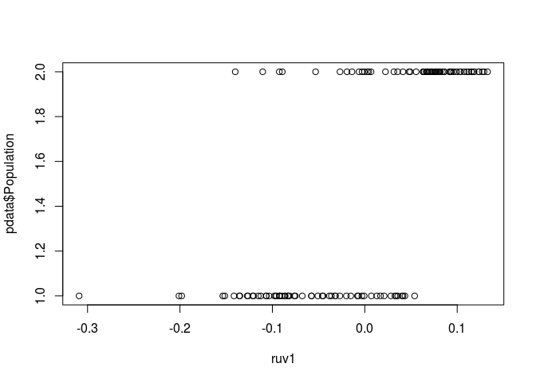

```r
ruv1 <- corrected$W_1
plot(ruv1, pdata$Population)
```

> Exercise 7: Fit a linear model correcting for the factor of unwanted variation. You can reuse the *DGEList* and again it is up to you to use `voom` or *edgeR*.

*Solution 7:*

```r
designruv <- model.matrix(~Gender, data = pdata)
designruv <- cbind(designruv, ruv1)
d2 <- estimateGLMCommonDisp(d, designruv)
d2 <- estimateGLMTagwiseDisp(d2, designruv)
fit <- glmFit(d2, designruv)
lrt <- glmLRT(fit, coef=2)
topTags(lrt)
```

```
## Coefficient:  Gendermale
##                      logFC    logCPM        LR        PValue           FDR
## ENSG00000099749  6.8445763 2.8199557 895.19775 1.085865e-196 9.865079e-193
## ENSG00000154620  4.9844685 2.8159354 707.45369 7.159163e-156 3.252050e-152
## ENSG00000198692  5.9826299 2.0777222 478.77093 3.955369e-106 1.197817e-102
## ENSG00000157828  5.5428435 1.8652709 386.21667  5.514714e-86  1.252529e-82
## ENSG00000129824  8.4317350 6.0815047 260.19970  1.552338e-58  2.820597e-55
## ENSG00000006757 -1.0949151 5.4385432 129.21990  6.070615e-30  9.191923e-27
## ENSG00000183878  3.6192409 0.4281880 117.34140  2.416732e-27  3.136572e-24
## ENSG00000174938  2.7581269 1.0325940  42.96180  5.581908e-11  6.338955e-08
## ENSG00000086712 -0.6130102 5.1559425  38.76326  4.784482e-10  4.829668e-07
## ENSG00000236696  2.2462485 0.7178029  37.95131  7.253235e-10  6.589564e-07
```

# Batch effect correction using *sva*

Now we will use the *sva*-package to estimate the unwanted variation introduced by the different populations.

> Exercise 8: What are the optimal number of surrogate variables to we should correct for?

*Solution 8:*

```r
suppressPackageStartupMessages(library(sva))
designsva <- model.matrix(~Gender, data = pdata)
n.sv <- num.sv(d$counts, designsva, method="leek")
n.sv
```

```
## [1] 125
```

If find this number too high and we can not even correct for all these; you will get a error-message if you try. I suppose we use just one!

> Exercise 9: To estimate the surrogate variable we need to define our null hypothesis. What is our null hypothesis? Run `svaseq`.

*Solution 9:*

```r
designsva0 <- model.matrix(~1, data = pdata)
svseq <- svaseq(d$counts, designsva, designsva0, n.sv=1)
```

```
## Number of significant surrogate variables is:  1
## Iteration (out of 5 ):1  2  3  4  5
```

> Exercise 10: Can you think of a way to see what the estimated unwanted variation represents? What does it represent?

*Solution 10:*

```r
plot(svseq$sv, pdata$Population)
```

[output not shown]

> Exercise 11: Fit a linear model correcting for the surrogate variable. You can reuse the `DGEList` and again it is up to you to use `voom` or *edgeR*.

*Solution 11:*

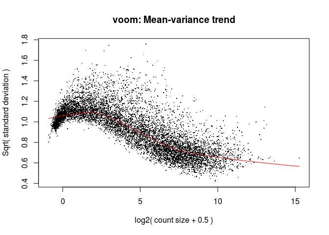

```r
designsva <- cbind(designsva, svseq$sv)
v <- voom(d, designsva, plot = TRUE)
```

```r
fit <- lmFit(v, designsva)
fit <- eBayes(fit)
summary(decideTests(fit))
```

```
##    (Intercept) Gendermale
## -1        1555          7 2763
## 0          482       9053 3861
## 1         7048         25 2461
```

```r
topTable(fit)
```

```
## Removing intercept from test coefficients

##                   Gendermale        V2      AveExpr          F
## ENSG00000129824  8.604150936  1.705214  2.303870943 1352.26926
## ENSG00000099749  5.391838113  2.565670  0.560818136  586.85774
## ENSG00000154620  4.802311088  3.740992  0.917947739  426.27746
## ENSG00000198692  4.339271289  2.025716  0.062664870  257.74453
## ENSG00000157828  3.923322619  6.244545  0.003851596  252.24194
## ENSG00000177324 -0.006480034  8.986664 -1.734992706   93.23657
## ENSG00000139329  0.090034950  9.414627 -1.677449269   87.06571
## ENSG00000183878  1.525424768  4.865944 -1.185817065   86.50908
## ENSG00000135473  0.228049100 -9.796073  7.215823299   83.46547
## ENSG00000103995  0.378832893 -8.829990  6.102712562   75.87484
##                      P.Value    adj.P.Val
## ENSG00000129824 1.746683e-88 1.586862e-84
## ENSG00000099749 2.647499e-66 1.202626e-62
## ENSG00000154620 3.127155e-58 9.470067e-55
## ENSG00000198692 3.018749e-46 6.856333e-43
## ENSG00000157828 9.334988e-46 1.696167e-42
## ENSG00000177324 6.006371e-26 9.094647e-23
## ENSG00000139329 8.122270e-25 1.054155e-21
## ENSG00000183878 1.032616e-24 1.172665e-21
## ENSG00000135473 3.898092e-24 3.934907e-21
## ENSG00000103995 1.209273e-22 1.098625e-19
```

# References

Frazee, A. C., B. Langmead, and J. T. Leek. 2011. “ReCount: a multi-experiment resource of analysis-ready RNA-seq gene count datasets.” *BMC Bioinformatics* 12: 449.

Montgomery, S. B., M. Sammeth, M. Gutierrez-Arcelus, R. P. Lach, C. Ingle, J. Nisbett, R. Guigo, and E. T. Dermitzakis. 2010. “Transcriptome genetics using second generation sequencing in a Caucasian population.” *Nature* 464 (7289): 773–77.

Pickrell, J. K., J. C. Marioni, A. A. Pai, J. F. Degner, B. E. Engelhardt, E. Nkadori, J. B. Veyrieras, M. Stephens, Y. Gilad, and J. K. Pritchard. 2010. “Understanding mechanisms underlying human gene expression variation with RNA sequencing.” *Nature* 464 (7289): 768–72.